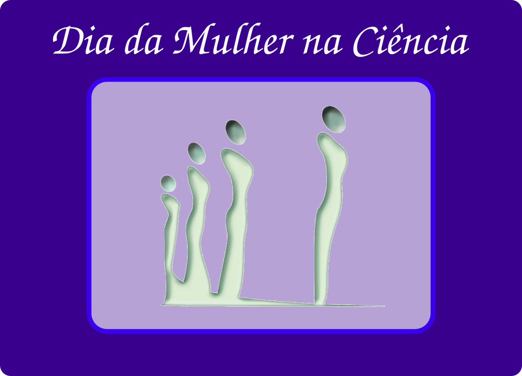

Em 22 de dezembro de 2015, um momento histórico aconteceu na 70ª sessão da Assembléia Geral das Nações Unidas: proclamou-se 11 de fevereiro como o **Dia Internacional das Mulheres e Meninas na Ciência**. A ação foi resultado de uma ideia compartilhada por representantes da UNESCO (Organização das Nações Unidas para a Educação, a Ciência e a Cultura), ONU Mulheres, Organização Mundial da Saúde, UNRWA (Agência das Nações Unidas de Assistência aos Refugiados da Palestina), UNICEF (Fundo das Nações Unidas para a Infância), UNFPA (Fundo de Populações das Nações Unidas) e do movimento mundial “Toda mulher toda criança” (“Every Woman Every Child”) no evento mundial da Saúde e Desenvolvimento da Mulher.

Entre as muitas colocações de autoridades sobre a data, está a do atual Secretário Geral das Nações Unidas, Antonio Guterres:

“Por muito tempo, estereótipos discriminatórios têm impedido mulheres e crianças de ter acesso igualitário à educação em ciência, tecnologia, engenharia e matemática (CTEM). Como um engenheiro treinado e professor formado, eu sei que estes estereótipos estão plenamente errados. Eles negam à mulheres e meninas a oportunidade de realizar seu potencial - e privam o mundo da genialidade e inovação provinda de metade da população. Neste dia Internacional, eu proclamo compromisso com o fim desse viés, maiores investimentos em educação CTEM para todas as mulheres e meninas, assim como oportunidades para suas carreiras e avanços profissionais para que todos possam ser beneficiados pelas inovadoras contribuições futuras.”

O [logo](https://womeninscienceday.org/WISID_WP/logo/) elaborado para este dia mostra grandes mulheres na ciência, as quais iniciaram a construção de um caminho para aquelas que vêm depois, tornando-se modelos, e servindo de inspiração e motivação para as próximas gerações. A cor do logo mostra igualdade, equidade e paridade, mostrando que a ciência pertence a todos os cidadãos e cidadãs.

Pelas reconhecidas organizações e personalidades envolvidas, já é possível perceber a importância da data proclamada. A desigualdade de gênero na ciência pode parecer uma realidade distante para muitos de nós, afinal, vemos mulheres por todos os lados aqui, não é mesmo? Mas vamos verificar alguns dados já coletados a respeito, porque nós cientistas gostamos de analisá-los e porque eles foram o motivo para que as organizações criassem a data de conscientização.

De acordo com um estudo feito pela ONU, apenas 30% dos cientistas do mundo são mulheres. Outro estudo feito pela UNESCO (2014-2016) aponta que, das mulheres cientistas, apenas 30% seguem as áreas CTEM na formação superior. A organização aponta como uma causa dessa desigualdade os estereótipos de gênero existentes. Na revista Science, foi publicado um artigo mostrando que o efeito dos estereótipos impostos culturalmente passam a afetar as crianças a partir de 6 ou 7 anos, resultando na desassociação de personalidades brilhante de sucesso à uma pessoas do sexo feminino.

A maior preocupação é que, estima-se que 65% das crianças que estão na escola hoje, terão empregos no futuro, ainda não existentes na atualidade. Grande parte desses novos empregos surgirão das áreas CTEM, e as meninas serão significativamente prejudicadas por não adentrarem nessas áreas.

Além disso, atualmente, mulheres têm menos de dois terços das oportunidades econômicas que os homens. E com o desenvolvimento da CTEM, essa diferença tende a aumentar.

Outros dados:

- 97% dos prêmios Nobel foram entregues a homens;
- De acordo com um estudo em 14 países, a probabilidade de mulheres obterem o grau de licenciatura, mestrado e doutoramento em campos relacionados com a ciência é de 18%, 8% e 2%, respectivamente; enquanto que as porcentagens masculinas são de 37%, 18% e 6%;
- Apenas 20% dos revisores de revistas científicas são mulheres; Se analisadas as bolsas de pesquisa do CNPq nacionais, as mulheres só aparecem com maior frequência em bolsas institucionais que são escolhidas internamente por cada grupo de estudo. Para cargos de maior destaque, a escolha da vaga é concebida ao Comitê Nacional Centralizado no Órgão, majoritariamente composto por homens.

E sabem o que podemos fazer para quebrarmos esses estereótipos impostos? Valorizar e destacar as mulheres que hoje estão na ciência. Assim, damos o exemplo para as próximas. Mostramos que, além de não precisar ser homem para ser cientista admirável, também não precisa ser aquela cientista tímida de óculos fundo de garrafa (mas pode ser também!). Existe um grande número de mulheres cientistas notáveis que precisam ser reconhecidas e exaltadas para que possam atingir alguma mulher ou menina que esteja só esperando por uma imagem para se identificar, inspirar e motivar. Por isso, nesta data, o grupo GENt destaca algumas mulheres cientistas admiráveis. Confira os cartazes nos corredores do departamento e vamos juntos(as) trabalhar para que existam menos barreiras para termos maior diversidade de personalidades e ideias no meio científico. Todos saímos ganhando!

# Saiba mais sobre as cientistas incríveis e admiráveis que temos hoje no nosso departamento

Você sabia que, pelo nosso departamento, já passaram 55 professores e apenas 10 deles eram mulheres? E atualmente somos privilegiados(as) pela presença de seis delas:

## [Claudia Barros Monteiro-Vitorello](http://buscatextual.cnpq.br/buscatextual/visualizacv.do?id=K4727307H9)

Mestre e Doutora em Agronomia pela ESALQ/USP, com passagem pela Michigan State University. Atualmente ela é Professora Associada do Departamento de Genética. A sua pesquisa tem enfoque na interação entre plantas de interesse agronômico e patógenos.

## [Elizabeth Ann Veasey](http://buscatextual.cnpq.br/buscatextual/visualizacv.do?id=K4780018E2)

Mestre e Doutora em Agronomia pela ESALQ/USP. Atualmente é Professora Doutora do Departamento de Genética. Estuda diversidade genética de populações de Espécies Nativas – como arroz e espécies de orquídeas – e Etnovariedades de Plantas Cultivadas – como urucum, mandioca, inhame e outros.

## [Margarida Lopes Rodrigues de Aguiar-Perecin](http://buscatextual.cnpq.br/buscatextual/visualizacv.do?id=K4783480J1)

Doutora em Agronomia pela ESALQ/USP. Passou por muitas instituições de prestígio, como a Universidade de Oxford. Em 2008 aposentou-se como Professora Titular e hoje é Professora Sênior no Departamento de Genética. Iniciou sua carreira científica em Citogenética de Aves mas autuou fortemente na área de Citogenética Vegetal.

## [Maria Carolina Quecine-Verdi](http://buscatextual.cnpq.br/buscatextual/visualizacv.do?id=K4704904D9)

Doutora em Agronomia pela ESALQ/USP, com passagem na Oregon State University. Foi Embaixadora Jovem do Brasil na Sociedade Americana de Microbiologia. Atualmente é Professora Doutora do Departamento de Genética. Sua pesquisa tem enfoque na interação microrganismos-planta e também na área de biologia molecular.

## [Maria Lucia Carneiro Vieria](http://buscatextual.cnpq.br/buscatextual/visualizacv.do?id=K4727688D6)

Mestre pela UFPR e Doutora em Agronomia pela ESALQ/USP. Passou pela Universidade de Nottingham e pela Universidade de Paris. Foi Presidente Substituta da CTNBio/MCTIC e é Membra da Coordenação de área da FAPESP – Biologia. Sua pesquisa tem foco na Construção de mapas genético-moleculares, Mapeamento de genes e Genômica.

## [Silvia Maria Guerra Molina](http://buscatextual.cnpq.br/buscatextual/visualizacv.do?id=K4785374E9)

Mestre em Agronomia pela ESALQ/USP e Doutora pela Unicamp. Atualmente é Professora Associada do Departamento de Genética. Atua na pesquisa na área de Ecologia Humana e de Genética e Biotecnologia Ambiental.

Você conhece essas pesquisadoras ou mais alguma que tenha passado pela história? Conte para nós! Nos ajude a registrar!

**Referências**

https://peerj.com/articles/4000/

http://science.sciencemag.org/content/355/6323/389

http://www.unwomen.org/en/news/in-focus/international-day-of-women-and-girls-in-science

https://womeninscienceday.org/WISID_WP/logo/

https://www.obaricentrodamente.com/2018/02/dia-internacional-das-mulheres-e-meninas-na-ciencia.html